# IE 582 - Statistical Learning for Data Mining - Project Report

Can Hakan Dagidir

```r
require(glmnet)
require(ggplot2)
require(data.table)
require(glmnet)
require(rpart)
require(rattle)
require(skimr)
require(tidyverse)
require(dplyr)
require(caret)
library(maptree)
library(ranger)
library(e1071)
library(gbm)
require(randomForest)
require(stats)
library(cluster)
#require(tidymodels)
```

```r
data_backup <- read.csv("/Users/canhakan/Desktop/IE 582/PROJE/IE582_Fall20_ProjectTrain.csv", header = TRUE)
```

# Introduction

## Problem Definition

**DATA:** We are given a dataset with ~2000 instances, 60 features and 1 binary class to predict. Also we know that there is a class imbalance in our dataset with 1:3 ratio. There are no missing values in the dataset and there are no labeling of the dataset.

**PROBLEM:** We are expected to do a binary classification.

**PERFORMACES:** We will be evaluated with Balanced Accuracy and Area Under ROC curve scores. These scores make sure that we give enough value to both of the classes.

**ROAD MAP:** We first need to find some methods for solving the class imbalance problem. Then we can also try to reduce the number of features as there are 60 of them. Then we will try different classification models to fit our data.

# Observatory Data Analysis

## Main observations

As we have explained before our data has a class imbalance problem. Also 47 of its 60 features are binary and 13 of them are integers(continuous).

Inspecting the training and test data we see that x50 x52 x37 and x57 are constants at least in one of the sets. So we can remove them.

Also let’s look at some notable variables with strict distinctions between class a and b.

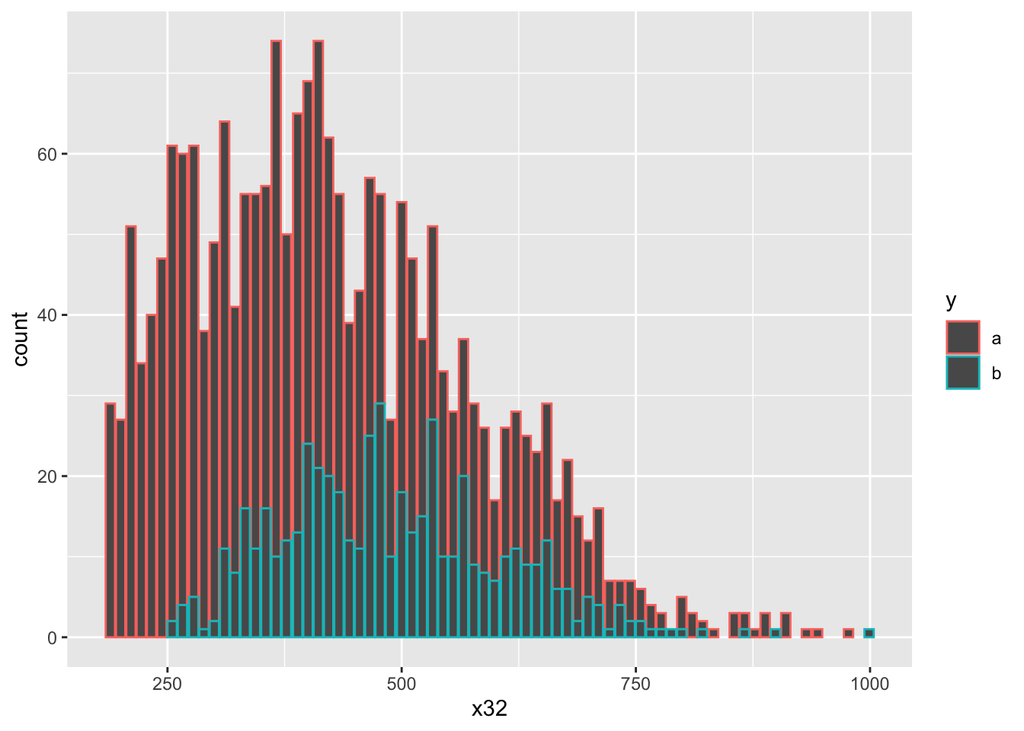

```r
ggplot(data = data_backup, mapping = aes(x = x32, col = y)) +
  geom_bar()
```

We can see that for x32<250, we only have instances from class a.

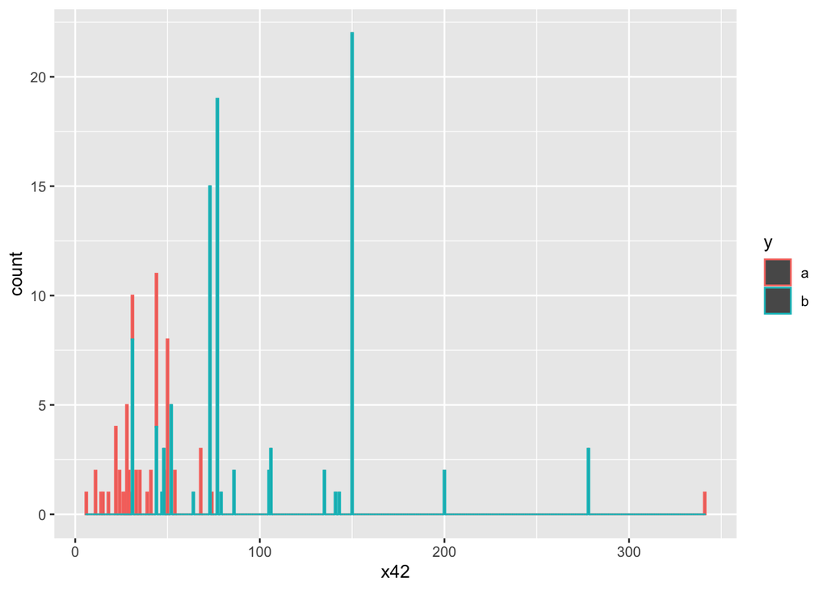

```r
# x42 in detail (without 0s and the single 10000) # buradaki 1000i direkt atalim
ggplot(data = data_backup[data_backup$x42!=0 & data_backup$x42<999,], mapping = aes(x = x42, colour = y)) +
  geom_histogram(binwidth = 1)
```

Here after removing the single point at x42=1000 and not including zeros, we can see that all but one instances with x42>75 are from class b.

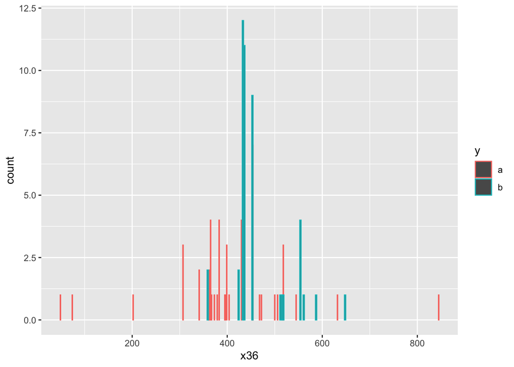

```r
# x36 nonzerolar
ggplot(data = data_backup %>% filter(x36!=0), mapping = aes(x = x36, col = y)) +
  geom_bar()
```

Excluding the values at zero, we can see that there is a distinction of classes in the plot of x36 too.

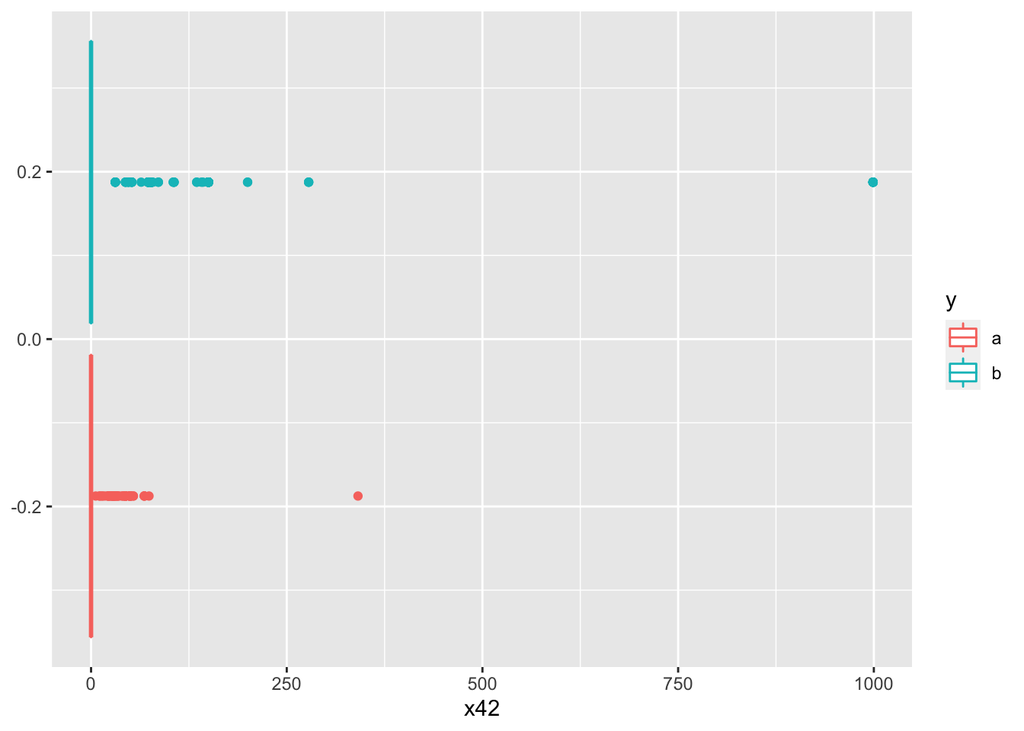

```r
# we can see that x42 has some outliers BOXPLOT
ggplot(data = data_backup, mapping = aes(x = x42, col = y)) +
  geom_boxplot()
```

We can see that x42 has some outliers. We can remove these values, too.

Now let’s run a DT to visualize the data for us a little bit.

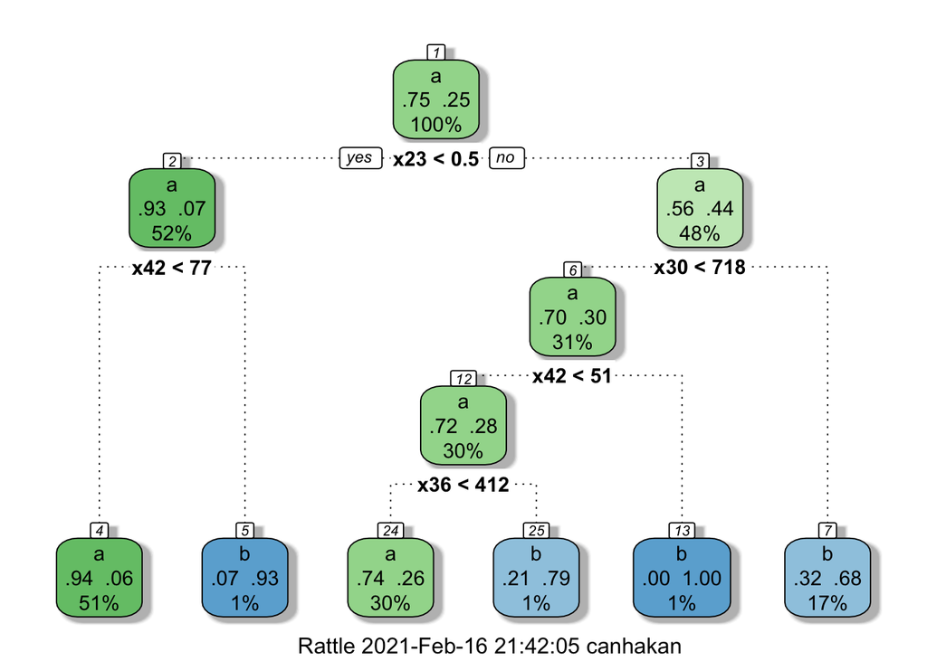

```r
dtfit <- rpart(y~.,data_backup)
fancyRpartPlot(dtfit)
```

We can see that x23 splits data in an interesting way. On the right branch we have a almost balanced dataset with around 1000 instances and on the left we have ~900 a with ~70 b. Also splitting left once more gives even purer nodes. Instead of trying some theoritic approaches we may split the data this way to avoid class imbalance problem.

# Preparing data

## Removing Low Varianced Ones

First of all we remove the constant columns. Also we saw that there were some columns with very little variance, we also remove them for some cases.

## PCA

Principal Component Analysis is another approach for feature reduction. After doing PCA we were able to reduce the dimensions around 35 with not many data loss. However Lever et al.<sup>(9)</sup> showed that in supervised learning problems, principal components may be misleading. We have tried PCA results with some models but the results were not as good so we won’t be inspecting them in more detail.

## Standardazing

We should standardize our data before applying these models. Because we don’t want the features with just high numbers to dominate our models.

Scaling before applying SVM is very important. Part 2 of Sarle’s Neural Networks FAQ, Sarle explains the importance of this and most of considerations also apply to SVM.<sup>(2)</sup>

## Solving Class Imbalance

### Downsampling

Downsampling is taking the same size of samples from each class with reffering to the minority class.

When there is a class imbalance but the minority class has enough number of instances to make learning models perform well downsampling is a preferred method.

One should be careful as with sampling less from the majority class some valuable information may be lost. So one may create more than one training samples with different samples from the majority class.

### Adding Class Weights

Adding class weights or up-weighting is penalizing the misclassification on the minority class more. It is also beneficial as we don’t need to remove more data from the majority class.

### Cloning Minority Class

When we don’t want to remove any of the data (except training/test split) we can just clone the minority class. It is useful but it gives some misleading informations.

### Synthetic Minority Oversampling Technique (didnt use but worth noting)

Synthetic Minority Oversampling Technique is creating synthetic instances very similar to the existing instances from the minority class. This way there are no duplicate instances as opposed to cloning.

### Splitting Data (Decision Tree Visual)

As shown above, the decision tree showed that our data can be splitted in a way that we can have some big chunks of data without class imbalance.

# Approaches and Results

## Elastic Net

The elastic net is an example of a shrinkage method which contains both Lasso and Ridge regression as special cases. The elastic net allows tuning of the penalty term
$$\lambda \left(\frac{1}{2}\left(1-\alpha \right){\boldsymbol{\beta}}^2+\alpha \left|\boldsymbol{\beta} \right|\right),$$
of the penalty equation:
$$\underset{\left({\beta}_0,\boldsymbol{\beta} \right)}{\min }{\left(\boldsymbol{y}-{\beta}_0-{\boldsymbol{X}}^T\boldsymbol{\beta} \right)}^2+\lambda \left(\frac{1}{2}\left(1-\alpha \right){\boldsymbol{\beta}}^2+\alpha \left|\boldsymbol{\beta} \right|\right),$$
through the parameter α.The parameter α controls the type of shrinkage, with important consequences for the properties of the estimation method. The penalty parameter λ controls the amount of shrinkage.(1)

### Parameters to be tuned

Lambda and Alpha as explained above. We will select 10 values for alpha from $[0,1]$ such as 0.1, 0.2… Then we will tune our lambdas for each alpha value with the help of ‘glmnet’ package.

### Results

An example result with lambda calculated from ‘cv.glmnet’ with alpha=0.5. Also used class weights accordingly. Below we can see the confusion matrix and Balanced Accuracy. Class based accuracies are also close to each other as: 77% and 83%.

```r
load('glmnet1.rda')
confMatW
```

```
## Confusion Matrix and Statistics
##
##           Reference
## Prediction    a    b
##          a 1096   76
##          b  313  383
##
##                Accuracy : 0.7918
##                  95% CI : (0.7726, 0.81)
##     No Information Rate : 0.7543
##     P-Value [Acc > NIR] : 7.253e-05
##
##                   Kappa : 0.5215
##
##  Mcnemar's Test P-Value : < 2.2e-16
##
##             Sensitivity : 0.7779
##             Specificity : 0.8344
##          Pos Pred Value : 0.9352
##          Neg Pred Value : 0.5503
##              Prevalence : 0.7543
##          Detection Rate : 0.5867
##    Detection Prevalence : 0.6274
##       Balanced Accuracy : 0.8061
##
##        'Positive' Class : a
##
```

## Random Forest

The random samplingand ensemble strategies utilized in RF enable it to achieve accurate predictions as well as better generalizations. This generalization property comes from the baggingscheme which improves the generalization by decreasing variance, while similarmethods like boosting achieve this by decreasing bias.<sup>(7)</sup>

random forests are particularly useful for high-dimensional datasets because increased classiﬁcation accuracy can be achieved by generating multiple prediction models each with a different feature subset. <sup>(6)</sup>

### Parameters and how to choose them

mtry = 5,7,9,13 ($\sqrt{n} \sim 8$) <sup>(4)</sup>

min.node.size = 10. Also we may try 30 just to see.

number of trees = 500 <sup>(5)</sup>

splitrule = gini <sup>(4)</sup>

### Results

Here is some results from the random forest fit without any attempts on adressing class imbalance.

```r
# load("rf0.rda")
# rf0$results
load("rf1.rda")
rf1$results
```

| mtry | splitrule | min.node.size | ROC | Sens | Spec | ROCSD | SensSD | SpecSD |
| --- | --- | --- | --- | --- | --- | --- | --- | --- |
| 5 | gini | 10 | 0.8787508 | 0.9478594 | 0.4911862 | 0.0139115 | 0.0148347 | 0.0458426 |
| 5 | gini | 30 | 0.8788048 | 0.9509265 | 0.4762182 | 0.0146266 | 0.0138919 | 0.0428447 |
| 7 | gini | 10 | 0.8787026 | 0.9442812 | 0.5135935 | 0.0144146 | 0.0131107 | 0.0444936 |
| 7 | gini | 30 | 0.8788776 | 0.9459425 | 0.4998214 | 0.0144622 | 0.0147254 | 0.0425098 |
| 9 | gini | 10 | 0.8775762 | 0.9405751 | 0.5222093 | 0.0144572 | 0.0143177 | 0.0456177 |
| 9 | gini | 30 | 0.8781962 | 0.9417252 | 0.5100524 | 0.0149675 | 0.0156593 | 0.0435703 |
| 13 | gini | 10 | 0.8764760 | 0.9355911 | 0.5383382 | 0.0157805 | 0.0150612 | 0.0449093 |
| 13 | gini | 30 | 0.8772204 | 0.9369968 | 0.5304718 | 0.0146539 | 0.0140938 | 0.0499141 |

We see that class a has high accuracy around 94% but class b is around 50%.

A result after downsampling the training set and training again:

```r
load("rf1down.rda")
rf1down$results
```

| mtry | splitrule | min.node.size | ROC | Sens | Spec | ROCSD | SensSD | SpecSD |
| --- | --- | --- | --- | --- | --- | --- | --- | --- |
| 7 | gini | 30 | 0.878189 | 0.7520024 | 0.8519000 | 0.0316742 | 0.0519531 | 0.041369 |
| 8 | gini | 30 | 0.878051 | 0.7515086 | 0.8479976 | 0.0329902 | 0.0449170 | 0.041371 |

We see that ROC value is very similar to above but our balanced accuracy improved and our classes have more balanced accuracy values.

We would be expecting around 85% final score with that result. However we did not send these findings as we were trying to finalize our SVM approach.

### The Alternative Approach

I have tried splitting the data to only two parts with referencing ‘x23’. Then I applied a random forest learner to the balanced side and sent the other node as class ‘a’ with sacrificing %14 from the class b score. I was planning to optimize it even more but the time was not enough. It was just a trial submission but it turned out to be my final submission. Also surprisingly our expected score was calculated 74% which is nice given the %14 sacrifise. Below you can find the simple for loop I made for submission:

```r
load('mantest.rda') # manual testing dataset

ccres <- c() # result
# a = 0
# b = 1
for(i in 1:nrow(mantest)){
  print(i)
  if(mantest[i,]$x23==0){
    if(mantest[i,]$x42<77){
      ccres <- c(ccres,0) # can be tuned between 0 and 0.15
    }else{
      ccres <- c(ccres,1) # can be tunned between 1 and 0.90~
    }
  }else{
    temp = predict(ccrf2,mantest[i,])
    k <- as.character(temp[[1]])
    if(k=='a'){
      t = 0
    }else{
      t = 1
    }
    ccres <- c(ccres, t)
  }
}
```

## SVM

SVM needs to be tuned well. It is suggested that trying a wide range for cost and trying very small lambdas are needed for tuning.

We are interested in RBF (radial basis function kernel) as it would probably give better results than other SVM types in our case<sup>(3)</sup>.

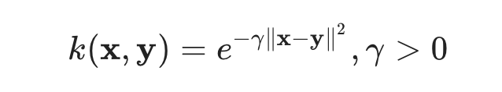

RBF

Looking at literature we see that Cost can differ a lot. So we try a big grid.

Notes: Using ‘caret’ caused a lot troubles for me. Finally I have found some results but using it to predict on the real test data gave me a single class. Also tuning the class weights were really messy. I was changing weights from 1:3 to 1:30000 and get same result but also trying 1:2.5 would sometimes give all ‘b’.

At the end I did my own loop for grid and cross validation and compared balanced error rates. I’ve found best the balanced error rates around 79-80%.

However, using these parameters to make predictions on the real test data gave %100 pure results as above. So I could not make submissions with that method. Probably I could not use that fit correctly at first, then trying to create another fit with same parameters on the training data without cv created a very different fit. I am not sure, yet.

### Parameters

COST : First we start from 2<sup>-5</sup> to 2<sup>15</sup> by 2<sup>2</sup>. As the cost increases model may overfit the data.

GAMMA : From 2<sup>-15</sup> to 2<sup>3</sup> by 2<sup>2</sup>. As explained in the formula.

CLASS WEIGHTS : Tried 3 (as it supposed to be) but scaling it between 2.4-3-8 was also gave good results.

### Results

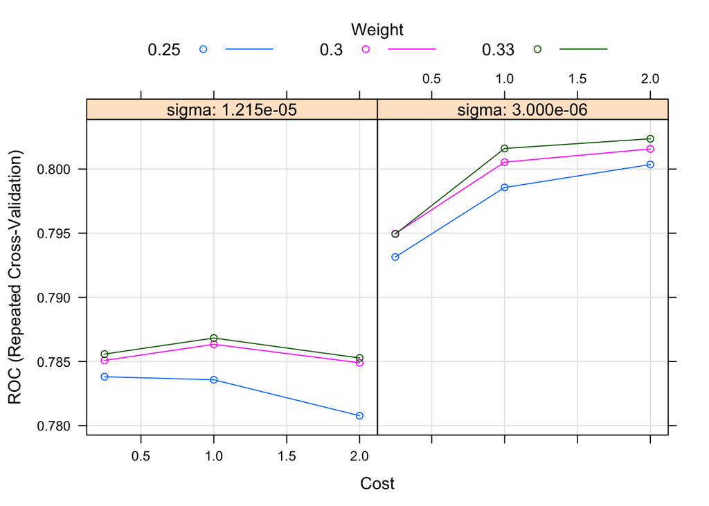

```r
load('svm403.rda')
plot(svm403)
```

# Personal Notes

R packages should be studied more before using, I have lost many many hours with trying to tune the wrong parameters. Also sometimes it is not possible as their guides/descriptions may be missing and even they might not be customizable to our needs. Especially at SVM I ‘wasted’ 2 days just to make the learning model I intend to work.

# Future Work

As the results are not finalized, I am planning finish the above approaches. Trying different class imbalance solutions such as SMOTE may also be useful. Also I am planning to create a General Additive Model fit for this problem.

Also studying Poisson’s works may also be useful for class imbalance problems with high imbalance.

# Conclusion

Class imbalance is a significant problem that forces almost all training methods to have a bias. Even though our dataset has a small class imbalance compared to some other real life scenarios such as ‘bankruptcy rate of companies’.

We have seen that with different approaches we can improve the balanecd performance of our methods with losing a little. There were not enough findings for comparison of the approaches but we have observed that random forests performed better than support vector machines even though SVM’s main function is distincting two classes in high-dimensional datasets.

# References

1 - Jerome Friedman, Trevor Hastie and Rob Tibshirani. (2008). Regularization Paths for Generalized LinearModels via Coordinate Descent Journal of Statistical Software, Vol. 33(1), 1-22 Feb 2010.

2 - Sarle, W. S., Neural Network FAQ, (1997.) URL ftp://ftp.sas.com/pub/neural/FAQ.html. Periodic posting to the Usenet newsgroup comp.ai.neural-nets.

3 - Keerthi, S. S., & Lin, C.-J. (2003). Asymptotic Behaviors of Support Vector Machines with Gaussian Kernel. Neural Computation, 15(7), 1667–1689. https://doi.org/10.1162/089976603321891855

4 - Probst, P., Wright, M. N., & Boulesteix, A. (2019). Hyperparameters and tuning strategies for random forest. Wiley Interdisciplinary Reviews: Data Mining and Knowledge Discovery, 9(3). https://doi.org/10.1002/widm.1301

5 - Oshiro, T. M., Perez, P. S., & Baranauskas, J. A. (2012). How Many Trees in a Random Forest? Lecture Notes in Computer Science, 154–168. doi:10.1007/978-3-642-31537-4_13

6 - Yang, P., Hwa Yang, Y., B. Zhou, B., & Y. Zomaya, A. (2010). A Review of Ensemble Methods in Bioinformatics. Current Bioinformatics, 5(4), 296–308. https://doi.org/10.2174/157489310794072508

7 - Qi, Y. (2012). Random Forest for Bioinformatics. In Ensemble Machine Learning (pp. 307–323). Springer US. https://doi.org/10.1007/978-1-4419-9326-7_11

9 - Lever, J., Krzywinski, M., & Altman, N. (2017). Principal component analysis. Nature Methods, 14(7), 641–642. https://doi.org/10.1038/nmeth.4346